# Analysis of Equities in BIST30 Index (XU030 Index)

Data Jugglers

November 21, 2018

# 1) Needed Libraries

```r
library(ggthemes)
library(Hmisc)
library(gridExtra)
library(GGally)
library(tibble)
library(dplyr)
library(tidyr)
library(reshape2)
library(tidyverse)
library(ggplot2)
library(corrgram)
library(corrplot)
library(date)
library(readxl)
library(knitr)
```

Setting theme

```r
theme_set(theme_economist())
```

# 2) Data Preparations

In this project, we are analyzing the BIST30 members as of November 2018. The data set consist of last price ad volume data of equities listed in BIST30 Index from January 2011 to November 2018. Firstly, *we have examined the data structure and,* made some little transformation in the columns of data frame.

```r
tmp<-tempfile(fileext=".xlsx")
download.file("https://github.com/MEF-BDA503/gpj18-data-jugglers/blob/master/XU030_v2.xlsx?raw=true",destfile=tmp,mode='wb')

bist30=read_xlsx(tmp)
```

```r
str(bist30$Dates)
range(bist30$Dates)
head(bist30)
tail(bist30)
```

# 3) Beta Analysis

**Normalization**: Before starting beta analysis, we should normalize the data as we take date 01.01.2011 equals to 100 for all stocks’ price.

```r
tmp<-tempfile(fileext=".xlsx")
download.file("https://github.com/MEF-BDA503/gpj18-data-jugglers/blob/master/XU030_v2.xlsx?raw=true",destfile=tmp,mode='wb')
bist30=read_xlsx(tmp)

bist30 <- cbind(bist30, apply(bist30[seq(2,60,2)], 2, function (a) a / a[[1]] * 100))

colnames(bist30)[62:91] <- paste(colnames(bist30[seq(2,60,2)]), "norm", sep = "_")

head(bist30[62:90],3)
```

# 4) Correlation and Regression Analysis of Volume and Price

## 1) Correlation Tables for Normalized and Raw Data

**Corrplot** is a good source for correlation table, we can see the desired relations between two values in table by looking the correlation table. In this graph we use normalized data set.

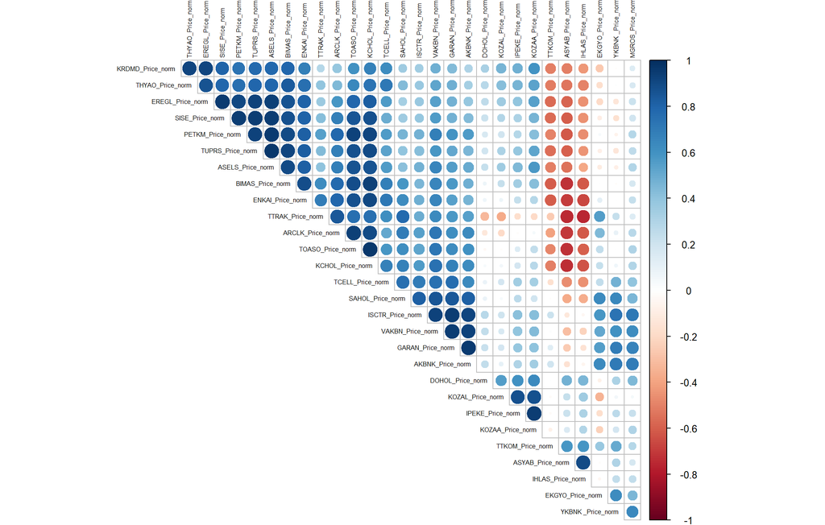

```r
corrValuesPrices <- cor(bist30[62:90],bist30[62:90])
corrplot(corrValuesPrices, type = "upper", tl.pos = "td",
         method = "circle", tl.cex = 0.5, tl.col = 'black',
         order = "hclust", diag = FALSE)
```

## 2) The Correlation Values between Volume and Price

We should investigate that is there any meaningful connection between volume values and price values. If there is, we can assuma some predictions about company stock’s volumes or prices from another.

First we need company names vector for table

```r
companyNames <- c('GARAN','SAHOL','BIMAS','ARCLK','EREGL','YKBNK','TOASO','TUPRS','KRDMD','TTRAK','ASELS','IPEKE','KOZAA','ASYAB','ENKAI','KOZAL','DOHOL','IHLAS','KCHOL','EKGYO','TCELL','MGROS','SISE','ISCTR','VAKBN','AKBNK','PETKM','THYAO','TTKOM','HALKB')
```

After that, we can apply correlatio between all the prices and volumes.

```r
df <- bist30
corGaran <- cor(df$GARAN_Price,df$GARAN_Volume)
corSahol <- cor(df$SAHOL_Price,df$SAHOL_Volume)
corBimas <- cor(df$BIMAS_Price,df$BIMAS_Volume)
corArclk <- cor(df$ARCLK_Price,df$ARCLK_Volume)
corEregl <- cor(df$EREGL_Price,df$EREGL_Volume)
corYkbnk <- cor(df$`YKBNK _Price`,df$`YKBNK _Volume`)
corToaso <- cor(df$TOASO_Price,df$TOASO_Volume)
corTuprs <- cor(df$TUPRS_Price,df$TUPRS_Volume)
corKrdmd <- cor(df$KRDMD_Price,df$KRDMD_Volume)
corTtrak <- cor(df$TTRAK_Price,df$TTKOM_Volume)
corAsels <- cor(df$ASELS_Price,df$ASELS_Volume)
corIpeke <- cor(df$IPEKE_Price,df$IPEKE_Volume)
corKozaa <- cor(df$KOZAA_Price,df$KOZAA_Volume)
corAsyab <- cor(df$ASYAB_Price,df$ASYAB_Volume)
corEnkai <- cor(df$ENKAI_Price,df$ENKAI_Volume)
corKozal <- cor(df$KOZAL_Price,df$KOZAL_Volume)
corDohol <- cor(df$DOHOL_Price,df$DOHOL_Volume)
corIhlas <- cor(df$IHLAS_Price,df$IHLAS_Volume)
corKchol <- cor(df$KCHOL_Price,df$KCHOL_Volume)
corEgkyo <- cor(df$EKGYO_Price,df$EKGYO_Volume)
corTcell <- cor(df$TCELL_Price,df$TCELL_Volume)
corMgros <- cor(df$MGROS_Price,df$MGROS_Volume)
corSise <- cor(df$SISE_Price,df$SISE_Volume)
corIsctr <- cor(df$ISCTR_Price,df$ISCTR_Volume)
corVakbn <- cor(df$VAKBN_Price,df$VAKBN_Volume)
corAkbnk <- cor(df$AKBNK_Price,df$AKBNK_Volume)
corPetkm <- cor(df$PETKM_Price,df$PETKM_Volume)
corThyao <- cor(df$THYAO_Price,df$THYAO_Volume)
corTtkom <- cor(df$TTKOM_Price,df$TTKOM_Volume)
corHalkb <- cor(df$HALKB_Price,df$HALKB_Volume)

corVec <- c(corGaran,corSahol,corBimas,corArclk,corEregl,corYkbnk,corToaso,corTuprs,corKrdmd,corTtrak,corAsels,corIpeke,corKozaa,corAsyab,corEnkai,corKozal,corDohol,corIhlas,corKchol,corEgkyo,corTcell,corMgros,corSise,corIsctr,corVakbn,corAkbnk,corPetkm,corThyao,corTtkom,corHalkb )
```

```r
corrTable <- melt(data.frame(companyNames ,corVec))
corrTable$variable <- NULL
corrTable
```

**CorVec** variable keeps the correlation values between prices and volumes . There are negative and positive values. The absolute value of correlation means the relationship of these two variables are more predictable and more meaningfull for future actions. Thus, investigating these correlation values could help for regression values to seek which stocks are the best for prediction.

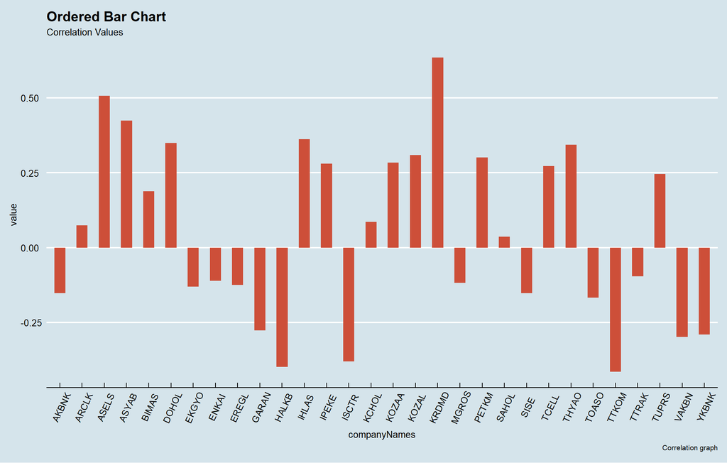

```r
corrTable %>% arrange(desc(value)) %>%
ggplot( aes(x=companyNames, y=value)) +
  geom_bar(stat="identity", width=.5, fill="tomato3") +
  labs(title="Ordered Bar Chart",
       subtitle="Correlation Values",
       caption="Correlation graph") +
  theme(axis.text.x = element_text(angle=65, vjust=0.6))
```

Arranging to absolute values

```r
corrTable %>% arrange(desc(abs(value)))
```

## 3) General Template for Highly Correlated Values

[figure not shown]

```r
ggpairs(df,
        columns = c("KRDMD_Price","KRDMD_Volume","ASELS_Price","ASELS_Volume","ASYAB_Price","ASYAB_Volume","TTKOM_Price","TTKOM_Volume","HALKB_Price","HALKB_Volume"),
        upper = list(continuous = wrap("cor",
                                       size = 10)),
        lower = list(continuous = "smooth"))
```

## 4) Highly Correlated Price Values

First, we need to see the relation of the price and volumes for each column.

```r
flattenCorrMatrix <- function(cormat, pmat) {
  ut <- upper.tri(cormat)
  data.frame(
    row = rownames(cormat)[row(cormat)[ut]],
    column = rownames(cormat)[col(cormat)[ut]],
    cor  =(cormat)[ut],
    p = pmat[ut]
    )
}
```

```r
corrData<-rcorr(as.matrix(df[,2:60]))
generalCorData <- flattenCorrMatrix(corrData$r, corrData$P)
generalCorData

generalCorData$Names <- paste(generalCorData$row,generalCorData$column,sep= "&")
```

Comparison of the results between each column correlation values to related price-volume correlation values

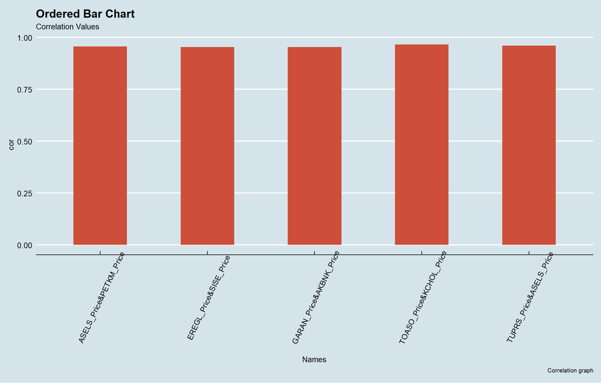

```r
generalCorData %>% arrange(desc(abs(cor))) %>%
  filter(cor > 0.95) %>%
ggplot( aes(x=Names, y=cor)) +
  geom_bar(stat="identity", width=.5, fill="tomato3") +
  labs(title="Ordered Bar Chart",
       subtitle="Correlation Values",
       caption="Correlation graph") +
  theme(axis.text.x = element_text(angle=65, vjust=0.6))
```

```r
generalCorData %>% arrange(desc(abs(cor))) %>%
  filter(cor > 0.95)
```

Also correlation with negative high values are preferable to include in portfolio

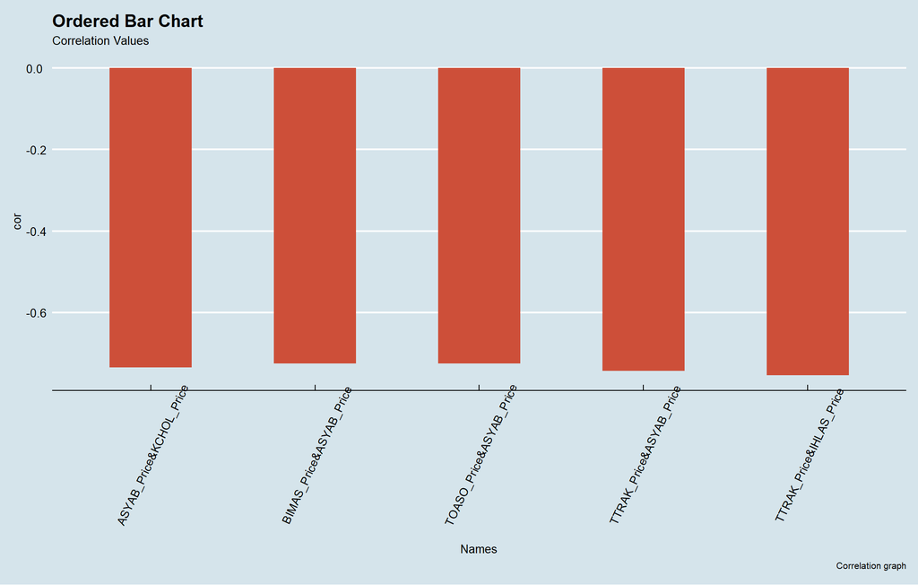

```r
generalCorData %>% arrange(desc(cor)) %>%
  filter(cor < -0.72) %>%
ggplot( aes(x=Names, y=cor)) +
  geom_bar(stat="identity", width=.5, fill="tomato3") +
  labs(title="Ordered Bar Chart",
       subtitle="Correlation Values",
       caption="Correlation graph") +
  theme(axis.text.x = element_text(angle=65, vjust=0.6))
```

Let’s draw these relations with **ggplot** library

Result: So there is a highly correlation between some prices. Therefore, if there is relation, we can examine the predictions on these values.

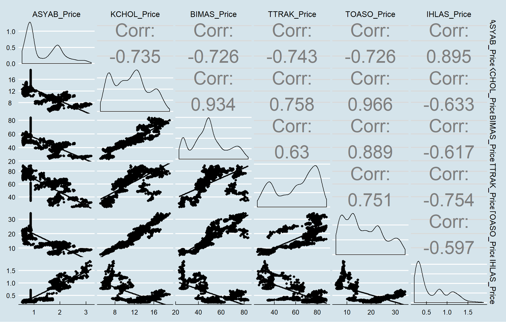

```r
ggpairs(df,
        columns = c("ASYAB_Price","KCHOL_Price","BIMAS_Price","TTRAK_Price","TOASO_Price","IHLAS_Price"),
        upper = list(continuous = wrap("cor",
                                       size = 10)),
        lower = list(continuous = "smooth"))
```

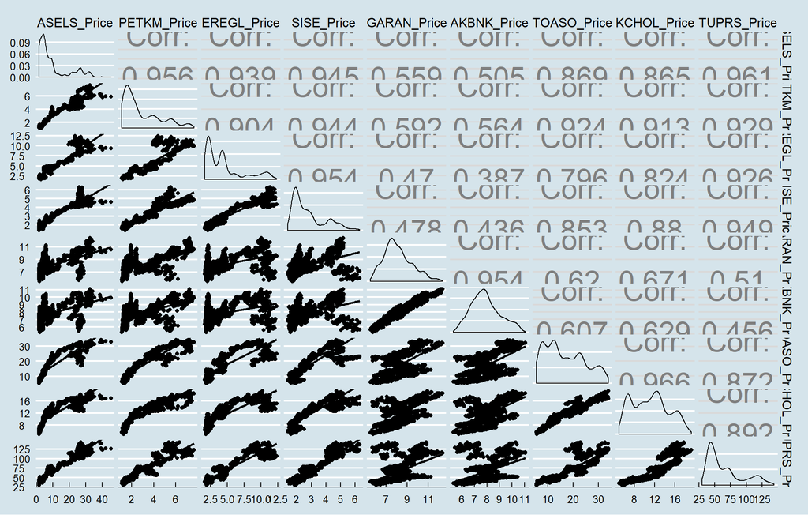

```r
ggpairs(df,
        columns = c("ASELS_Price","PETKM_Price","EREGL_Price","SISE_Price","GARAN_Price","AKBNK_Price","TOASO_Price","KCHOL_Price","TUPRS_Price"),
        upper = list(continuous = wrap("cor",
                                       size = 10)),
        lower = list(continuous = "smooth"))
```

# 5) Linear Models

## 1) Linear Regression Model for Mostly Correlated Volume-Price Values

We can analyze the first five company which have the highest correlation volume-price relation values of all.Thus, if we look at the correlation table of volume-price relation, we can see that:

**KRDMD** is the first one

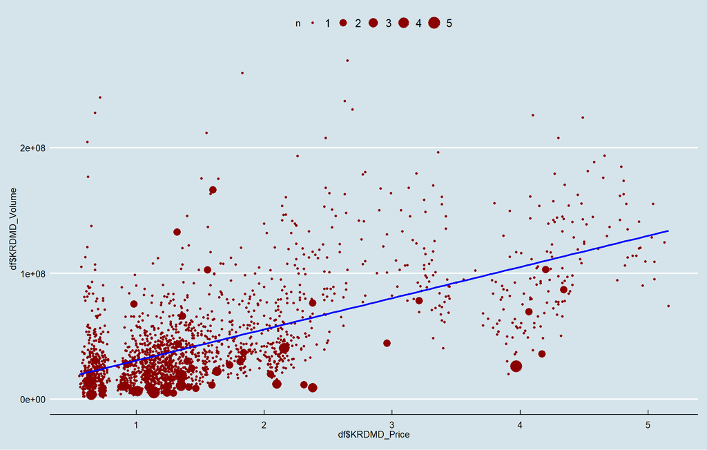

```r
ggplot(df, aes(df$KRDMD_Price, df$KRDMD_Volume)) +
  geom_count(color="darkred") +
  geom_smooth(method="lm", se=F,color="blue")
```

**ASELS** is the second one

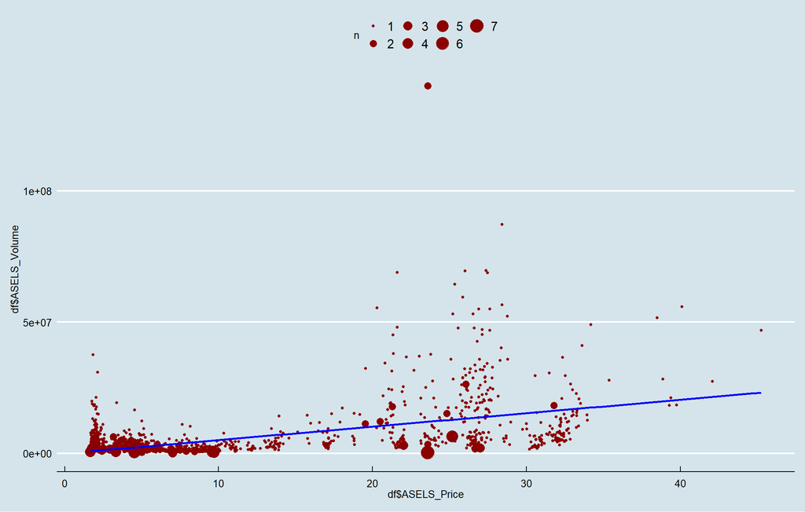

```r
ggplot(df, aes(df$ASELS_Price, df$ASELS_Volume)) +
  geom_count(color="darkred") +
  geom_smooth(method="lm", se=F,color="blue")
```

**ASYAB** is the third one

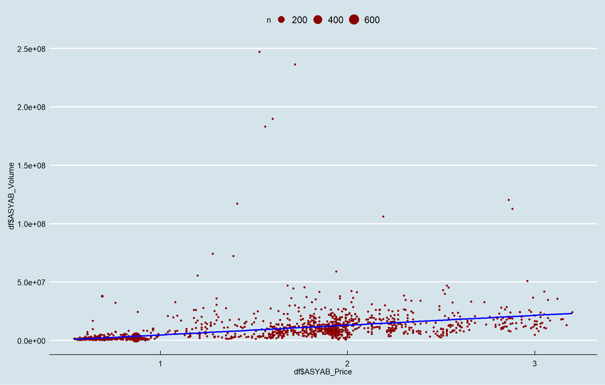

```r
ggplot(df, aes(df$ASYAB_Price, df$ASYAB_Volume)) +
  geom_count(color="darkred") +
  geom_smooth(method="lm", se=F,color="blue")
```

**TTKOM** is the forth one

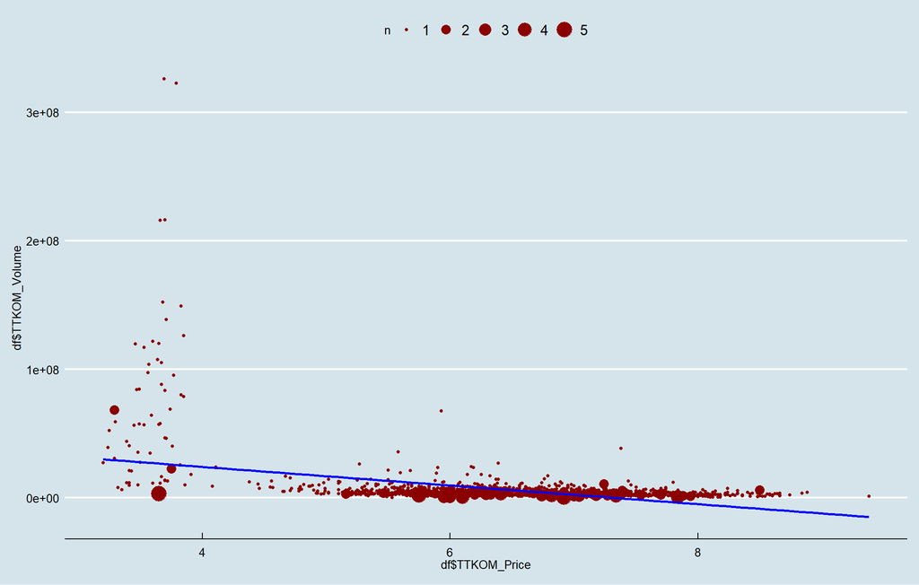

```r
ggplot(df, aes(df$TTKOM_Price, df$TTKOM_Volume)) +
  geom_count(color="darkred") +
  geom_smooth(method="lm", se=F,color="blue")
```

**HALKB** is the fifth one

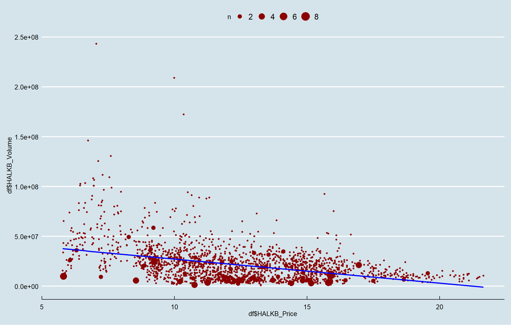

```r
ggplot(df, aes(df$HALKB_Price, df$HALKB_Volume)) +
  geom_count(color="darkred") +
  geom_smooth(method="lm", se=F,color="blue")
```

## 2) Linear Regression Charts for These Highly Correlated Prices

**TOASO & KCHOL** is the first one

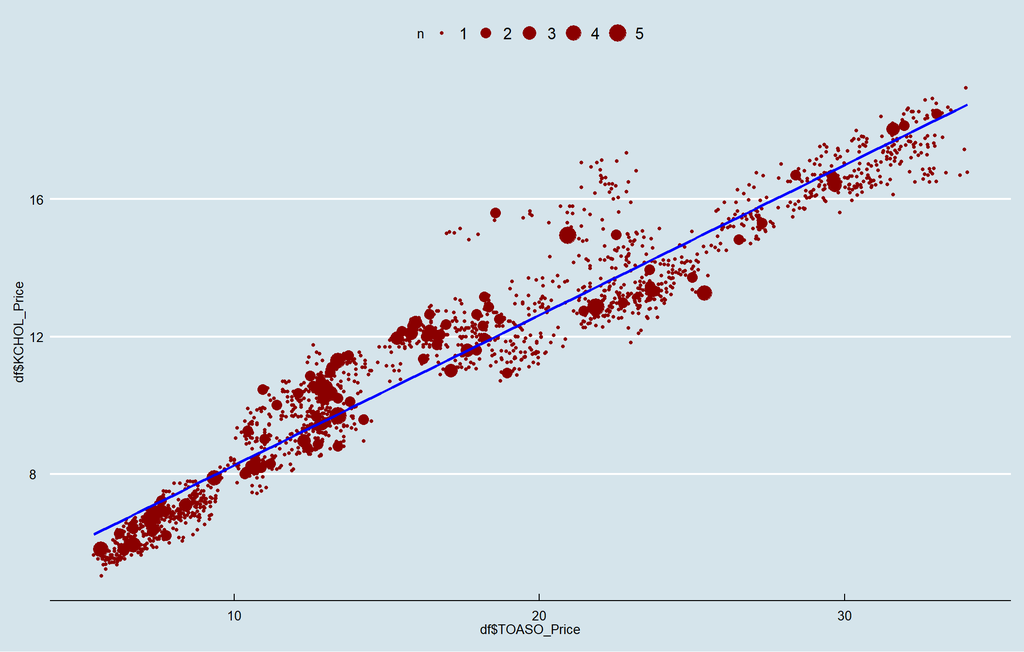

```r
ggplot(df, aes(df$TOASO_Price, df$KCHOL_Price)) +
  geom_count(color="darkred") +
  geom_smooth(method="lm", se=F,color="blue")
```

**TUPRS & ASELS** is the second one

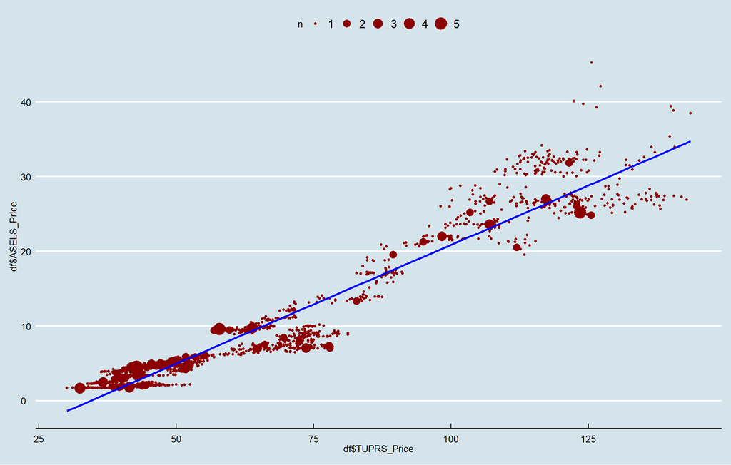

```r
ggplot(df, aes(df$TUPRS_Price, df$ASELS_Price)) +
  geom_count(color="darkred") +
  geom_smooth(method="lm", se=F,color="blue")
```

**ASELS & PETKM** is the third one

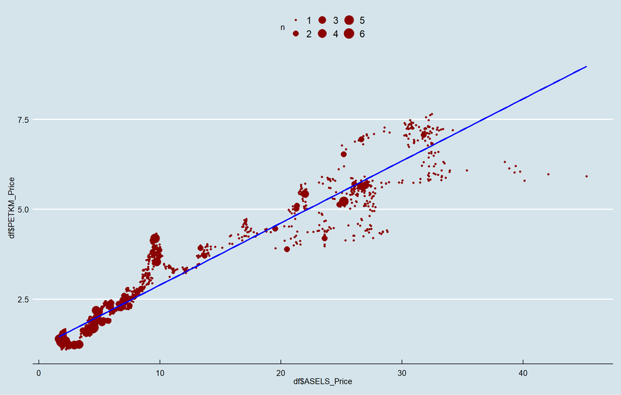

```r
ggplot(df, aes(df$ASELS_Price, df$PETKM_Price)) +
  geom_count(color="darkred") +
  geom_smooth(method="lm", se=F,color="blue")
```

**EREGL & SISE** is the forth one

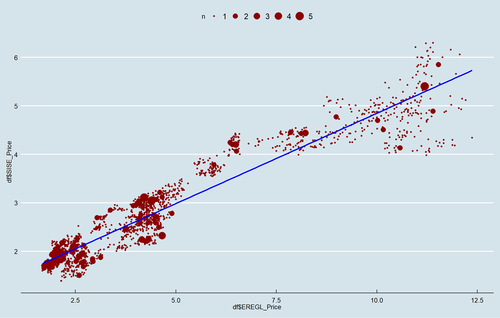

```r
ggplot(df, aes(df$EREGL_Price, df$SISE_Price)) +
  geom_count(color="darkred") +
  geom_smooth(method="lm", se=F,color="blue")
```

**GARAN & AKBNK** is the fifth one

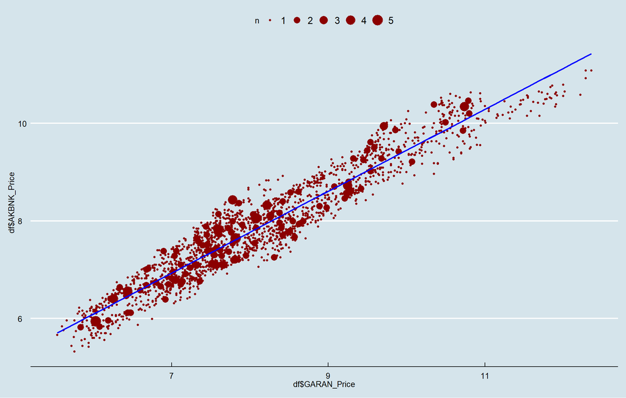

```r
ggplot(df, aes(df$GARAN_Price, df$AKBNK_Price)) +
  geom_count(color="darkred") +
  geom_smooth(method="lm", se=F,color="blue")
```

## 3) Linear Regression Charts for These Highly Negative Correlated Prices

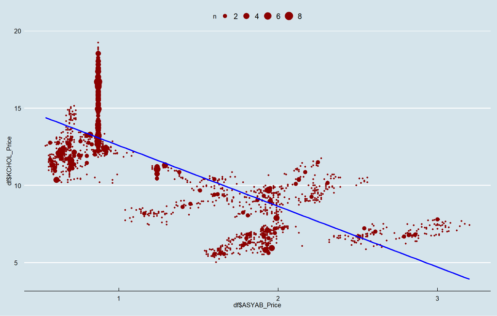

```r
ggplot(df, aes(df$ASYAB_Price, df$KCHOL_Price)) +
  geom_count(color="darkred") +
  geom_smooth(method="lm", se=F,color="blue")
```

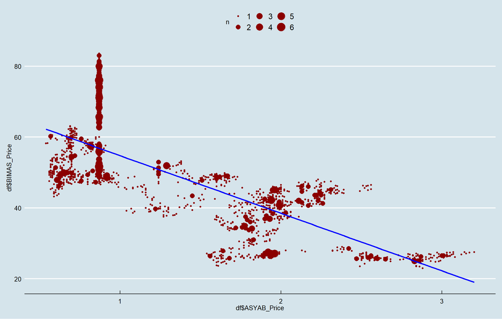

```r
ggplot(df, aes(df$ASYAB_Price, df$BIMAS_Price)) +
  geom_count(color="darkred") +
  geom_smooth(method="lm", se=F,color="blue")
```

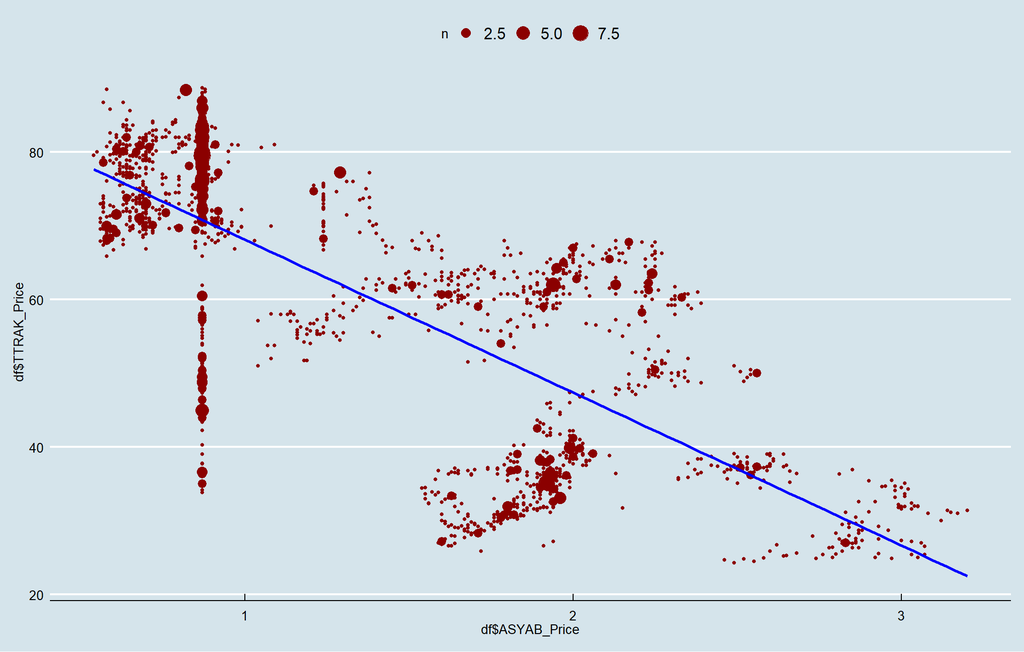

```r
ggplot(df, aes(df$ASYAB_Price, df$TTRAK_Price)) +
  geom_count(color="darkred") +
  geom_smooth(method="lm", se=F,color="blue")
```

**ASYAB & TOASO** is the forth one

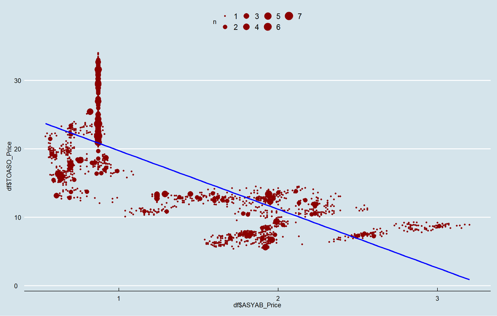

```r
ggplot(df, aes(df$ASYAB_Price, df$TOASO_Price)) +
  geom_count(color="darkred") +
  geom_smooth(method="lm", se=F,color="blue")
```

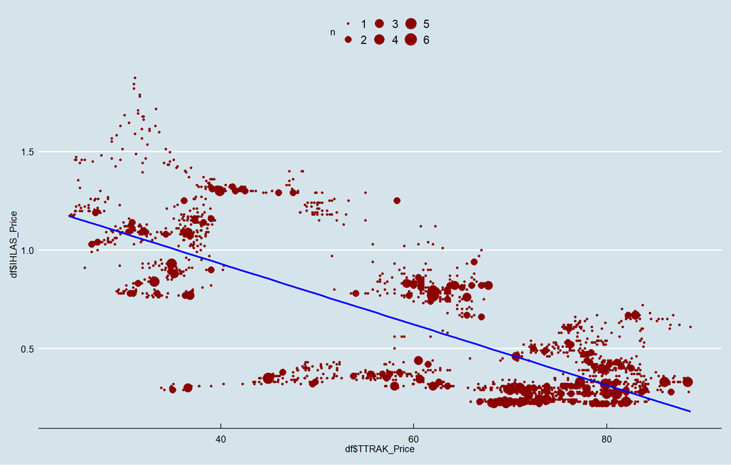

```r
ggplot(df, aes(df$TTRAK_Price, df$IHLAS_Price)) +
  geom_count(color="darkred") +
  geom_smooth(method="lm", se=F,color="blue")
```

## 4) Linear Models for These Highly Correlated Prices

With **lm** function we can see the relation between data as linear model

```r
linearMod1_1 <- lm(df$TOASO_Price ~ df$KCHOL_Price, data=df)
linearMod1_2 <- lm(df$TUPRS_Price ~ df$ASELS_Price, data=df)
linearMod1_3 <- lm(df$ASELS_Price ~ df$PETKM_Price, data=df)
linearMod1_4 <- lm(df$EREGL_Price ~ df$SISE_Price, data=df)
linearMod1_5 <- lm(df$GARAN_Price ~ df$AKBNK_Price, data=df)
summary(linearMod1_1)
summary(linearMod1_2)
summary(linearMod1_3)
summary(linearMod1_4)
summary(linearMod1_5)
```

Formula Model 1: $-7.17270 + 2.13500 * X$

Adjusted R-squared: $0.9331$

Formula Model 2: $36.75406 + 2.90503 * X$

Adjusted R-squared: $0.9238$

Formula Model 3: $-5.34984 + 5.29687 * X$

Adjusted R-squared: $0.9141$

Formula Model 4: $-2.34248 + 2.44400 * X$

Adjusted R-squared: $0.9108$

Formula Model 5: $-0.41338 + 1.08461 * X$

Adjusted R-squared: $0.9101$

The Adjusted R-squared values are really high. That’s why, we can say that, the prediction made between prices are highly elective and measurable.

## 5) Linear Models for These Specific Stocks

And **linear models** for these stocks are

```r
linearMod2_1<- lm(df$KRDMD_Price ~ df$KRDMD_Volume, data=df)
linearMod2_2 <- lm(df$ASELS_Price ~ df$ASELS_Volume, data=df)
linearMod2_3 <- lm(df$ASYAB_Price ~ df$ASYAB_Volume, data=df)
linearMod2_4 <- lm(df$TTKOM_Price ~ df$TTKOM_Volume, data=df)
linearMod2_5 <- lm(df$HALKB_Price ~ df$HALKB_Volume, data=df)
summary(linearMod2_1)
summary(linearMod2_2)
summary(linearMod2_3)
summary(linearMod2_4)
summary(linearMod2_5)
```

Formula Model 1: $8.495e-01 + 1.624e-08 * X$

Adjusted R-squared: $0.4025$

Formula Model 2: $7.391e+00 + 5.014e-07 * X$

Adjusted R-squared: $0.2563$

Formula Model 3: $1.183e+00 + 2.132e-08 * X$

Adjusted R-squared: $0.1787$

Formula Model 4: $6.662e+00 + -2.370e-08 * X$

Adjusted R-squared: $0.1714$

Formula Model 5: $1.375e+01 + -6.544e-08 * X$

Adjusted R-squared: $0.1586$

# 6) K-Means Analysis

We have divided the dataset into two groups as financial sector companies and real sector companies. Now we will check whether this classification is true or not by using k-means.

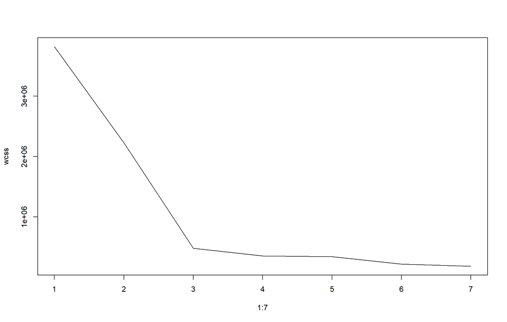

```r
#we calculate the annual average of stocks.
annual_average<- aggregate(bist30[,62:91], list(format(bist30$Dates, "%Y")), mean)
View(annual_average)

#get transpose of annual_average dataset.
transpose <- as.matrix(annual_average[,-1])
rownames(transpose) <- annual_average[,1]
annual_average <- t(transpose)
View(annual_average)

#lets define wcss(Within cluster sum of squares) vector.
wcss <- vector()

#lets find the distance to the center for each predefined center numbers.
for (i in 1:7) wcss[i] <- sum(kmeans(annual_average, i)$withinss)
View(wcss)

#lets determine the breakdown point of the wcss graph.
plot(1:7, wcss, type="l")
```

```r
#3 centers are the optimum number for centers.
kmeans(annual_average, 3)
```

## 6.1) Cluster Table

Structuring the table for **kmeans**.

```r
bist30_cluster<-kmeans(annual_average,centers=3)
rownames(annual_average)
bist30_cluster$cluster
##Get the clusters
results=data.frame(stocks=names(bist30_cluster$cluster), cluster_stocks=bist30_cluster$cluster) %>% arrange(cluster_stocks,stocks)
results[,1]
```

```r
c1 <- companyNames
c2 <- c(3,3,2,2,2,3,2,2,2,2,1,3,3,3,3,3,3,3,2,3,3,3,2,3,3,3,2,2,3,3)
clusterFrame <- melt(data.frame(c1,c2))
clusterFrame$variable <- NULL
names(clusterFrame) <- c("Companies","Groups")
```

Kmeans Cluster Table

| Companies | Groups |
| --- | --- |
| GARAN | 3 |
| SAHOL | 3 |
| BIMAS | 2 |
| ARCLK | 2 |
| EREGL | 2 |
| YKBNK | 3 |
| TOASO | 2 |
| TUPRS | 2 |
| KRDMD | 2 |
| TTRAK | 2 |
| ASELS | 1 |
| IPEKE | 3 |
| KOZAA | 3 |
| ASYAB | 3 |
| ENKAI | 3 |
| KOZAL | 3 |
| DOHOL | 3 |
| IHLAS | 3 |
| KCHOL | 2 |
| EKGYO | 3 |
| TCELL | 3 |
| MGROS | 3 |
| SISE | 2 |
| ISCTR | 3 |
| VAKBN | 3 |
| AKBNK | 3 |
| PETKM | 2 |
| THYAO | 2 |
| TTKOM | 3 |
| HALKB | 3 |

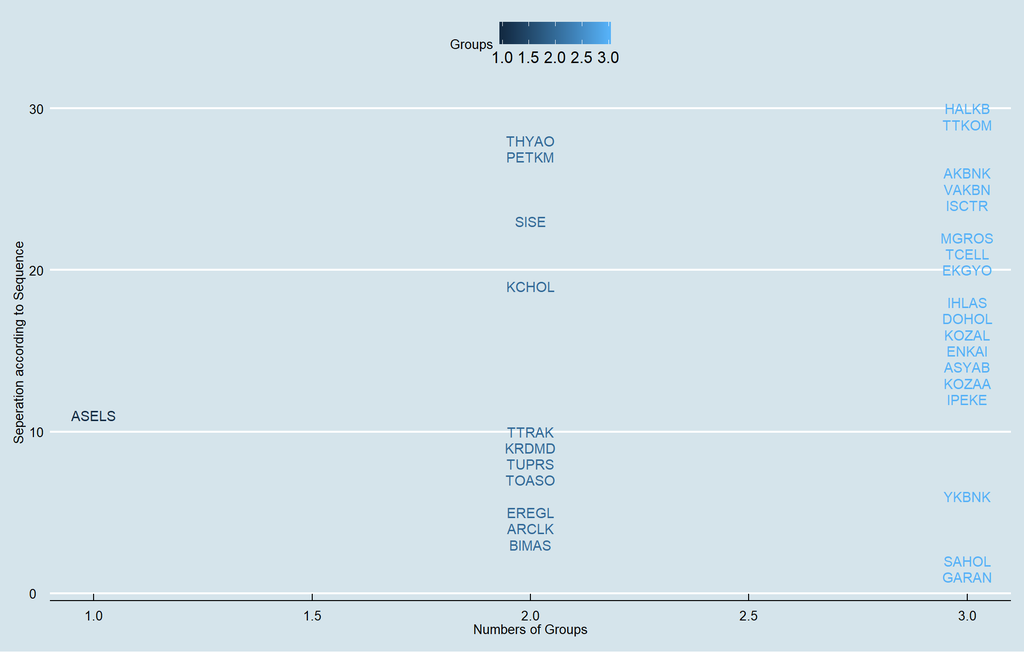

```r
ggplot(clusterFrame, aes(x =Groups , y = seq(1,30,1), colour = Groups,fill = Groups)) + geom_text(label = clusterFrame$Companies) +
  xlab(label = "Numbers of Groups") +
  ylab(label = "Seperation according to Sequence")
```

## 6.2) Sum of Squares

$$\frac{betweenSS}{totalSS} = 87.5$$

# 7) Comparison of Company Stocks

## 7.1) Equity Yields Comparison for the Selected Period

We can measure the change in prices by looking last and first 3 months average differences. The differences between last and first can show us what the yileds would be beneficial if we purchase these stocks at 2011.

```r
df1 <- head(bist30,n= 90)
df2 <- tail(bist30,n= 90)

averageFirst <- df1[0:61] %>% summarise_at(names(df1[0:61]), mean, na.rm = TRUE) %>%
  select(matches("price"))
averageLast <- df2[0:61] %>% summarise_at(names(df2[0:61]), mean, na.rm = TRUE) %>%
  select(matches("price"))

momentums <- (averageLast - averageFirst) / averageFirst
momentums
```

First, we should combine the company names and momentums

```r
df_momentums <-  as.data.frame(t(momentums))
momentumTable <-melt(data.frame(companyNames ,df_momentums))
momentumTable$variable <- NULL
momentumTable$companyNames <- paste(momentumTable$companyNames,"Momentum",sep= "&")
momentumTable %>% arrange(desc(value))
```

Lets visualize this

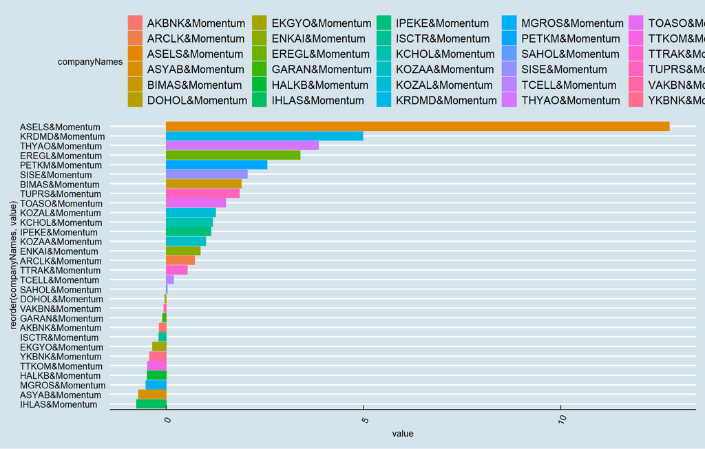

```r
momentumTable %>%
  arrange(desc(value)) %>%
  ggplot(data = ., aes(x = reorder(companyNames, value), y = value,
    fill = companyNames, color = companyNames)) + geom_bar(stat = 'identity') + theme(axis.text.x = element_text(angle=65, vjust=0.6)) + coord_flip()
```

## 7.2) Possible Highest Income Measure

We can find the max and min values of prices and calculate the measure of it. This will show us the a possible income for investor how to reach a maxiumum profit.

```r
maxVal <- bist30 %>% summarise_all("max") %>%
  select(matches("norm"))

minVal <- bist30 %>% summarise_all("min") %>%
  select(matches("norm"))


maxmin <- (maxVal-minVal) / minVal
maxmin
```

Then, we can turn this into a usable table

```r
df_maxmin <-  as.data.frame(t(maxmin))
maxminTable <-melt(data.frame(companyNames ,df_maxmin))
maxminTable$variable <- NULL
maxminTable$companyNames <- paste(maxminTable$companyNames,"MaxminRange",sep= "&")
maxminTable %>% arrange(desc(value))
```

Visualization of this

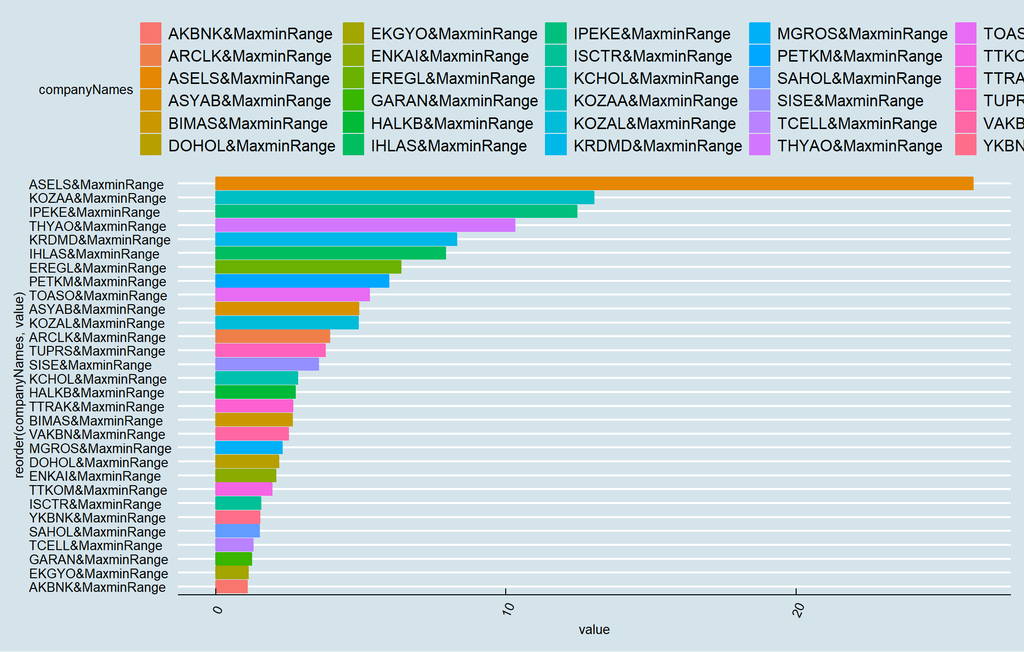

```r
maxminTable %>%
  arrange(desc(value)) %>%
  ggplot(data = ., aes(x = reorder(companyNames, value), y = value,
    fill = companyNames, color = companyNames)) + geom_bar(stat = 'identity') + theme(axis.text.x = element_text(angle=65, vjust=0.6)) + coord_flip()
```

## 7.3) Traded Value of Equities

The geometric average of volume and price can show us the economic value of companies. Thus, we can calculate this value and compare the companies by this.

```r
df_volume <- bist30[0:61] %>% summarise_at(names(bist30[0:61]), mean, na.rm = TRUE) %>%
  select(matches("Volume"))

df_prices <- bist30[0:61]%>% summarise_at(names(bist30[0:61]), mean, na.rm = TRUE) %>%
  select(matches("Price"))

volumes <- as.data.frame(t(df_volume))
prices <- as.data.frame(t(df_prices))
economicValue <- data.frame(companyNames,sqrt(volumes*prices))
```

Visualization of this data frame

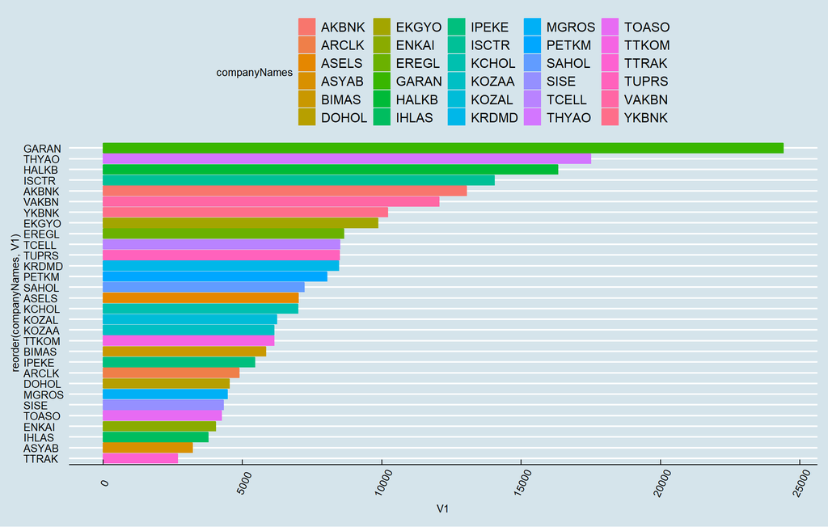

```r
economicValue %>%
  arrange(desc(V1)) %>%
  ggplot(data = ., aes(x = reorder(companyNames, V1), y = V1,
    fill = companyNames, color = companyNames)) + geom_bar(stat = 'identity') + theme(axis.text.x = element_text(angle=65, vjust=0.6)) + coord_flip()
```

## 7.4) Correlation of Economic Value and Momentums

**cor(economicValue,momentumTable)**

Correlation: $-0.09753649$

The information about companies and their stocks’ purchase has a correlation nearly -0.1 which is too low to guess about it. That’s why, economic values of companies are not good parameter for price predictions.

# 8) General Comperasion of Two Sector Banks and Others

## 8.1) Basic Average

```r
names(bist30)
bankStocks <- c("GARAN_Price_norm","VAKBN_Price_norm","AKBNK_Price_norm","YKBNK _Price_norm","ASYAB_Price_norm","HALKB_Price_norm","ISCTR_Price_norm")
```

Selecting from bist30 data table as made below

```r
newbist30 <- bist30[,62:91]
selectedComp1 <- newbist30[,bankStocks]
selectedComp2 <- newbist30[ , !(names(newbist30) %in% bankStocks)]
totalComp <- newbist30 %>% select(matches("norm"))
selectedComp2
```

Afer that, transpozing the vales help to summarise the values.

```r
selectedComp2 <-  as.data.frame(t(selectedComp2))
selectedComp1 <-  as.data.frame(t(selectedComp1))
totalComp <- as.data.frame(t(totalComp))
names(selectedComp2) <- bist30$Dates
names(selectedComp1) <- bist30$Dates
names(totalComp) <- bist30$Dates
selectedComp1
```

As you can see we summarise the values of normalized prices

```r
meanVal1 <- selectedComp1 %>% summarise_all(mean)
meanVal2 <- selectedComp2 %>% summarise_all(mean)
Totalmean <- totalComp %>% summarise_all(mean)
```

Then,naming and again transposing data to visualize in normal form

```r
newValue1<- as.data.frame(t(meanVal1))
newValue2 <- as.data.frame(t(meanVal2))
totalValue <-  as.data.frame(t(Totalmean))
names(newValue1) <- "Prices1"
names(newValue2) <- "Prices2"
names(totalValue) <- "TotalPrices"
```

Merging this data tables helps us to generate a mean table for sector and general companies.

```r
CompanyPrices <-data.frame(bist30$Dates,newValue1$Prices1,newValue2$Prices2,totalValue$TotalPrices)
names(CompanyPrices) <- c("Dates","bankSectorPrices","OtherPrices","TotalPrices")
CompanyPrices
```

The normalized prices of groups to the years

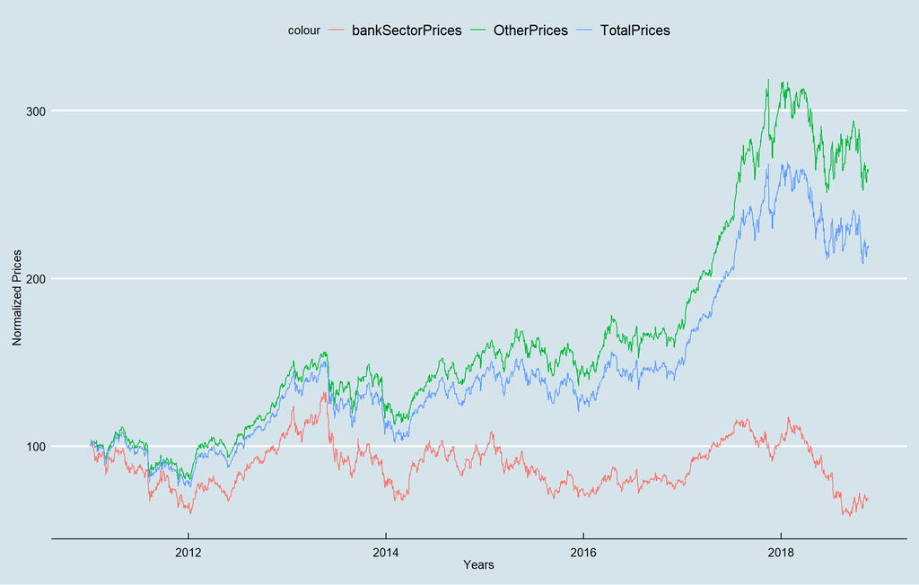

```r
ggplot(CompanyPrices, aes(x = Dates)) +
  geom_line(aes(y = bankSectorPrices, colour = "bankSectorPrices")) +
  geom_line(aes(y = OtherPrices, colour = "OtherPrices")) +
  geom_line(aes(y = TotalPrices, colour = "TotalPrices")) +
  xlab("Years") + ylab("Normalized Prices")
```

After all, banking sector is below of the other sectors by means of price values.